# Analysis of the most harmful events with respect to population and economics health

Evgeniia Golovina

27/01/2021

## Synopsis

According to the National Oceanic and Atmospheric Administration’s (NOAA) storm database, tornado and tsunami are the most harmful with respect to population health. In total, tornado caused 91346 injuries and 5633 fatalities, while tsunami caused more injuries and fatalities on average across the United States - 6.45 and 1.65 correspondingly.

With respect to economic health, drought, flood, and storm surge/tide have the greatest economic consequences. In total and on average, drought is the most harmfult event to crops. Crop estimates by drought is 13,972,566,000 in total and 9,198,529 an average. In terms of property damage, flood and storm surge/tide are the most dangerous to economics. Flood is the most harmful event in total damaging about 144,766,000,000 properties, while storm surge/tide is harmful on average - the mean number of property damage is equal to 32008193.

## 1. Data Processing

First, let’s download the storm database and read it. The database contains 37 variables and 902,297 observations.

```r
file_url <- "https://d396qusza40orc.cloudfront.net/repdata%2Fdata%2FStormData.csv.bz2"
temp <- tempfile(); download.file(file_url,temp)
file.copy(from = temp, to = paste0(getwd(),"/raw_data.csv.bz2")) # download zip file as raw_data.csv.bz2; returns FALSE if the file already exists
```

```
## [1] FALSE
```

```r
unlink(temp) # delete the temp file or use file.remove(temp)
df <- read.csv(bzfile("raw_data.csv.bz2")) # read the file as a dataframe
#str(df) # 37 variables and 902,297 observations
```

Let’s explore what types of events (i.e. EVTYPE variable) happened across the United States.

```r
event_type <- unique(df$EVTYPE)
#length(event_type) # 985 different types of events
```

In total, there are *985* different types of events happened across the United States. According to storm data event table from [Storm Data Documentation](https://d396qusza40orc.cloudfront.net/repdata%2Fpeer2_doc%2Fpd01016005curr.pdf), there are only 48 types of events. Our EVTYPE variable needs a preprocessing:

```r
# make all the letters lowercase
df$EVTYPE <- tolower(df$EVTYPE) # 898 different types of events
# remove extra spaces in the event names
df$EVTYPE <- str_squish(df$EVTYPE) # 883
# remove all observations that starts with "summary"
df <- df[!grepl("^summary", gsub("\\.", "", df$EVTYPE,)),] # 817
# remove "(" and ")" from names
df$EVTYPE <- gsub("\\(", "", df$EVTYPE,); df$EVTYPE <- gsub("\\)", "", df$EVTYPE,) # 815
# remove numbers in the beginning and the end of the name
df$EVTYPE <- gsub("^\\d+|\\d+$", "", df$EVTYPE) # 754
# remove extra spaces in the event names
df$EVTYPE <- str_squish(df$EVTYPE) # 746
# replace "winds", "wnd", "wins" with "wind"
df$EVTYPE <- gsub("winds", "wind", df$EVTYPE,); df$EVTYPE <- gsub("wnd", "wind", df$EVTYPE,)
df$EVTYPE <- gsub("wins", "wind", df$EVTYPE,) # 726
# replace "storms" with "storm"
df$EVTYPE <- gsub("storms", "storm", df$EVTYPE,) # 721
# replace "flooding" with "flood"
df$EVTYPE <- gsub("flooding", "flood", df$EVTYPE,) # 709
# replace "rains" with "rain"
df$EVTYPE <- gsub("rains", "rain", df$EVTYPE,) # 707
# replace "landslides" with "landslide"
df$EVTYPE <- gsub("landslides", "landslide", df$EVTYPE,) # 706
# replace "tornados" with "tornado"
df$EVTYPE <- gsub("tornados", "tornado", df$EVTYPE,) # 705
# replace "tstm" with "thunderstorm"
df$EVTYPE <- gsub("tstm", "thunderstorm", df$EVTYPE,) # 701
# replace "wild fires" with "wildfire"
df$EVTYPE <- gsub("wild fires", "wildfire", df$EVTYPE,) # 700
# remove extra spaces in the event names
df$EVTYPE <- str_squish(df$EVTYPE) # 698
# replace "winds", "wnd", "wins", "win", "windd" with "wind"
df$EVTYPE <- gsub("winds", "wind", df$EVTYPE,); df$EVTYPE <- gsub("wnd", "wind", df$EVTYPE,)
df$EVTYPE <- gsub("wins", "wind", df$EVTYPE,); df$EVTYPE <- gsub("win", "wind", df$EVTYPE,)
df$EVTYPE <- gsub("windd", "wind", df$EVTYPE,) # 696
# replace "windter" with "winter"
df$EVTYPE <- gsub("windter", "winter", df$EVTYPE,)
# replace "waterspout/tornado" with "waterspout tornado"
df$EVTYPE <- gsub("waterspout/tornado", "waterspout tornado", df$EVTYPE,)
# replace "thundersnow" and "thunderstormw" with "thunderstorm"
df$EVTYPE <- gsub("thundersnow", "thunderstorm", df$EVTYPE,)
df$EVTYPE <- gsub("thunderstormw", "thunderstorm", df$EVTYPE,)
# replace "lightning injury" with "lightning"
df$EVTYPE <- gsub("lightning injury", "lightning", df$EVTYPE,) # 691
# replace "cstl" with "coastal"
df$EVTYPE <- gsub("cstl", "coastal", df$EVTYPE,) # 690
# replace "fld" with "flood"
df$EVTYPE <- gsub("fld", "flood", df$EVTYPE,) # 689
# replace "currents" with "current"
df$EVTYPE <- gsub("currents", "current", df$EVTYPE,) # 689
# Subset only observations that have these 48 event types
events_48 <- c("astronomical low tide", "avalanche", "blizzard", "coastal flood", "cold/wind chill",
               "debris flow", "dense fog", "dense smoke", "drought", "dust devil", "dust storm",
               "excessive heat", "extreme cold/wind chill", "flash flood", "flood", "frost/freeze",
               "funnel cloud", "freezing fog", "hail", "heat", "heavy rain", "heavy snow", "high surf",
               "high wind", "hurricane typhoon", "ice storm", "lake-effect snow", "lakeshore flood",
               "lightning", "marine hail", "marine high wind", "marine strong wind",
               "marine thunderstorm wind", "rip current", "seiche", "sleet", "storm surge/tide",
               "strong wind", "thunderstorm wind", "tornado", "tropical depression", "tropical storm",
               "tsunami", "volcanic ash", "waterspout", "wildfire", "winter storm", "winter weather")

df_48 <- df[df$EVTYPE %in% events_48,] # 46 types of events
#length(unique(df_48$EVTYPE))
```

Let’s explore the CROPDM/CROPDMGEXP and PROPDM/PROPDMGEXP variables. We need to convert “K” for thousands, “M” for millions, and “B” for billions. We did the following transformations to clean the CROPDM/CROPDMGEXP and PROPDM/CROPDMGEXP variables:

1. Make all the letters lowercase
2. Include in the final dataset only observations that have “k”, “m” and “m” values for CROPDMGEXP and CROPDMGEXP variables.
3. Create a new variable with actual numbers for CROPDM and PROPDM to actual numbers after translating “K” to thousands, “M” to millions, and “B” to billions.
4. Subset the observations that have more than 0 amount for new variables.

```r
# make all the letters lowercase
df_48$CROPDMGEXP <- tolower(df_48$CROPDMGEXP)
df_48$PROPDMGEXP <- tolower(df_48$PROPDMGEXP)
# remove all observations that don't have "k", "m" or "b"
tr <- c("k", "m", "b")
df_48_cr <- df_48[df_48$CROPDMGEXP %in% tr,] # 282,592
df_48_pr <- df_48[df_48$PROPDMGEXP %in% tr,] # 431,652
# create new variables for crop
for(i in 1:length(df_48_cr$CROPDMGEXP)){
  if(df_48_cr$CROPDMGEXP[i]=="k"){
    df_48_cr$CROPDMGEXP[i] <- as.numeric(1000)
  } else if(df_48_cr$CROPDMGEXP[i]=="m"){
    df_48_cr$CROPDMGEXP[i] <- as.numeric(1000000)
  } else if(df_48_cr$CROPDMGEXP[i]=="b"){
    df_48_cr$CROPDMGEXP[i] <- as.numeric(1000000000)
  }
}
df_48_cr$CROPDMG_NEW <- df_48_cr$CROPDMG*as.numeric(df_48_cr$CROPDMGEXP)
# create new variables for property
for(i in 1:length(df_48_pr$PROPDMGEXP)){
  if(df_48_pr$PROPDMGEXP[i]=="k"){
    df_48_pr$PROPDMGEXP[i] <- as.numeric(1000)
  } else if(df_48_pr$PROPDMGEXP[i]=="m"){
    df_48_pr$PROPDMGEXP[i] <- as.numeric(1000000)
  } else if(df_48_pr$PROPDMGEXP[i]=="b"){
    df_48_pr$PROPDMGEXP[i] <- as.numeric(1000000000)
  }
}
df_48_pr$PROPDMG_NEW <- df_48_pr$PROPDMG*as.numeric(df_48_pr$PROPDMGEXP)
```

Let’s subset those events that have:

1. number of injuries > 0
2. number of fatalities > 0
3. crop damage amount > 0
4. property damage amount > 0

```r
sub_df_inj <- subset(df_48, df_48$INJURIES>0)
#length(unique(sub_df_inj$EVTYPE))
sub_df_fat <- subset(df_48, df_48$FATALITIES>0)
#length(unique(sub_df_fat$EVTYPE))
sub_df_crop <- subset(df_48_cr, df_48_cr$CROPDMG_NEW>0)
#length(unique(sub_df_crop$EVTYPE)) # 45
sub_df_prop <- subset(df_48_pr, df_48_pr$PROPDMG_NEW>0)
#length(unique(sub_df_prop$EVTYPE)) # 46
```

In total, there are *35* types of events that caused at least one injury, and there are *34* types of events that caused at least one fatality. In total, there are *27* types of events that lead to crop damage. And there are *45* types of events that cause property damage.

## 2. Results

To understand which types of events are most harmful with respect to population health, we are going to explore *35* types of events that caused at least one injury, and those that caused at least one fatality. First, let’s calculate the total number and mean of the injuries per each event type.

```r
event_inj <- unique(sub_df_inj$EVTYPE) # 35 types of events
df_48_inj <- df_48[df_48$EVTYPE %in% event_inj, ] # 882,748 observations for these 35 types of events
# get total number of injuries
inj_total <- df_48_inj %>% group_by(EVTYPE) %>% summarise(total_inj = sum(INJURIES))
# get the mean
inj_mean <- df_48_inj %>% group_by(EVTYPE) %>% summarise(mean_inj = mean(INJURIES))

max_tot_inj_event <- as.list(inj_total[inj_total$total_inj==max(inj_total$total_inj),]) # tornado - 91346 injuries
max_mean_inj_event <- as.list(inj_mean[inj_mean$mean_inj==max(inj_mean$mean_inj),]) # tsunami - 6.45
```

```r
event_fat <- unique(sub_df_fat$EVTYPE) # 34 types of events
df_48_fat <- df_48[df_48$EVTYPE %in% event_fat, ] # 873,475 observations for these 34 types of events
# get total number of injuries
fat_total <- df_48_fat %>% group_by(EVTYPE) %>% summarise(total_fat = sum(FATALITIES))
# get the mean
fat_mean <- df_48_fat %>% group_by(EVTYPE) %>% summarise(mean_fat = mean(FATALITIES))

max_tot_fat_event <- as.list(fat_total[fat_total$total_fat==max(fat_total$total_fat),]) # tornado - 5633 injuries
max_mean_fat_event <- as.list(fat_mean[fat_mean$mean_fat==max(fat_mean$mean_fat),]) # tsunami - 1.65
```

The figure below shows the total number of injuries and fatalities accross each event type. Overall, tornado had the total number of injuries - *91346*. The tornado had the total number of fatalities - *5633*.

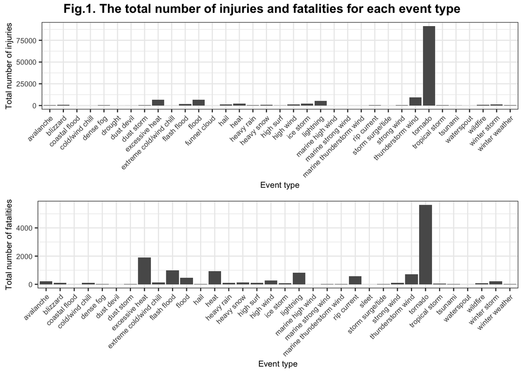

```r
# Barplots of total number of injuries and fatalities per event type
inj <- ggplot(inj_total, aes(inj_total$EVTYPE, inj_total$total_inj)) +
  geom_bar(position="dodge", stat="identity") +
  xlab("Event type") + ylab ("Total number of injuries") +
  theme_bw() +
  theme(axis.text.x = element_text(angle = 45, hjust=1, size = 7),
        axis.title.x = element_text(size = 8),
        axis.title.y = element_text(size = 8),
        axis.text.y = element_text(size = 7))

fat <- ggplot(fat_total, aes(fat_total$EVTYPE, fat_total$total_fat)) +
  geom_bar(position="dodge", stat="identity") +
  xlab("Event type") + ylab ("Total number of fatalities") +
  theme_bw() +
  theme(axis.text.x = element_text(angle = 45, hjust=1, size = 7),
        axis.title.x = element_text(size = 8),
        axis.title.y = element_text(size = 8),
        axis.text.y = element_text(size = 7))
# Arrange on one page
figure <- ggarrange(inj, fat, ncol = 1, nrow = 2)
annotate_figure(figure,
                top = text_grob("Fig.1. The total number of injuries and fatalities for each event type",
                                face = "bold", size = 12))
```

The figure below displays the average number of injuries for each event type.

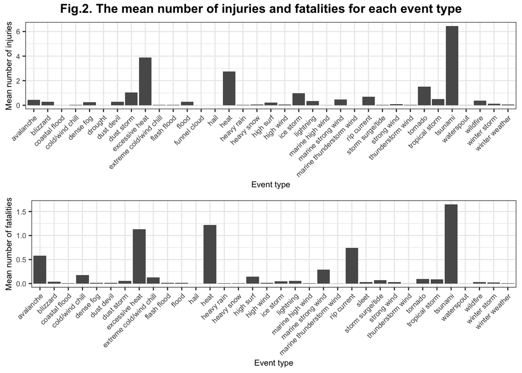

```r
# Barplots of mean number of injuries and fatalities per event type
inj_m <- ggplot(inj_mean, aes(inj_mean$EVTYPE, inj_mean$mean_inj)) +
  geom_bar(position="dodge", stat="identity") +
  xlab("Event type") + ylab ("Mean number of injuries") +
  theme_bw() +
  theme(axis.text.x = element_text(angle = 45, hjust=1, size = 7),
        axis.title.x = element_text(size = 8),
        axis.title.y = element_text(size = 8),
        axis.text.y = element_text(size = 7))

fat_m <- ggplot(fat_mean, aes(fat_mean$EVTYPE, fat_mean$mean_fat)) +
  geom_bar(position="dodge", stat="identity") +
  xlab("Event type") + ylab ("Mean number of fatalities") +
  theme_bw() +
  theme(axis.text.x = element_text(angle = 45, hjust=1, size = 7),
        axis.title.x = element_text(size = 8),
        axis.title.y = element_text(size = 8),
        axis.text.y = element_text(size = 7))
# Arrange on one page
figure_m <- ggarrange(inj_m, fat_m, ncol = 1, nrow = 2)
annotate_figure(figure_m,
                top = text_grob("Fig.2. The mean number of injuries and fatalities for each event type",
                                face = "bold", size = 12))
```

To understand which types of events have the greatest economic consequences across the united States, we focused on two parameters - new crop and property damage amounts we calculated for each event type.

```r
event_cr <- unique(sub_df_crop$EVTYPE) # 27 types of events
df_cr <- df_48_cr[df_48_cr$EVTYPE %in% event_cr, ]
# get total crop damage amount
cr_tot <- df_cr %>% group_by(EVTYPE) %>% summarise(tot_cr = sum(CROPDMG_NEW))
# get the mean
cr_mean <- df_cr %>% group_by(EVTYPE) %>% summarise(mean_cr = mean(CROPDMG_NEW))

max_tot_cr_event <- as.list(cr_tot[cr_tot$tot_cr==max(cr_tot$tot_cr),]) # drought - 13972566000
max_mean_cr_event <- as.list(cr_mean[cr_mean$mean_cr==max(cr_mean$mean_cr),]) # drought - 9198529
```

Overall, drought caused the maximum crop damadge - *1.397e+10*. The drought is also the most harmful on average across the United States - *9198529*.

```r
event_pr <- unique(sub_df_prop$EVTYPE) # 45 types of events
df_pr <- df_48_pr[df_48_pr$EVTYPE %in% event_pr, ]
# get total crop damage amount
pr_tot <- df_pr %>% group_by(EVTYPE) %>% summarise(tot_pr = sum(PROPDMG_NEW))
# get the mean
pr_mean <- df_pr %>% group_by(EVTYPE) %>% summarise(mean_pr = mean(PROPDMG_NEW))

max_tot_pr_event <- as.list(pr_tot[pr_tot$tot_pr==max(pr_tot$tot_pr),]) # flood - 1.44766e+11
max_mean_pr_event <- as.list(pr_mean[pr_mean$mean_pr==max(pr_mean$mean_pr),]) # storm surge/tide - 32008193
```

Overall, flood caused the total property damadge - *1.448e+11*. However, the storm surge/tide is the most harmful on average across the United States - *32008193*.

The figure below displays the average amount of crop and property damage for each event type.

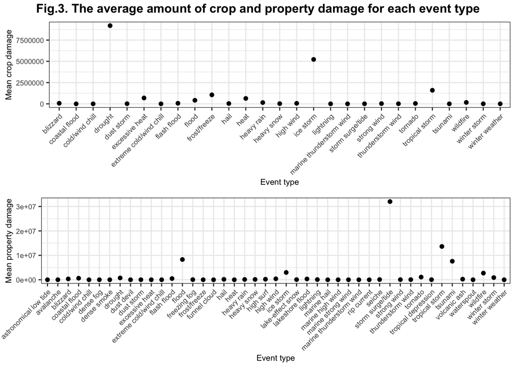

```r
# Mean number of crop damage amount per event type
cr <- ggplot(cr_mean, aes(cr_mean$EVTYPE, cr_mean$mean_cr)) + geom_point() +
  xlab("Event type") + ylab ("Mean crop damage") +
  theme_bw() +
  theme(axis.text.x = element_text(angle = 45, hjust=1, size = 7),
        axis.title.x = element_text(size = 8),
        axis.title.y = element_text(size = 8),
        axis.text.y = element_text(size = 7))
# Mean number of property damage amount per event type
pr <- ggplot(pr_mean, aes(pr_mean$EVTYPE, pr_mean$mean_pr)) + geom_point() +
  xlab("Event type") + ylab ("Mean property damage") +
  theme_bw() +
  theme(axis.text.x = element_text(angle = 45, hjust=1, size = 7),
        axis.title.x = element_text(size = 8),
        axis.title.y = element_text(size = 8),
        axis.text.y = element_text(size = 7))
# Arrange on one page
figure <- ggarrange(cr, pr, ncol = 1, nrow = 2)
annotate_figure(figure,
                top = text_grob("Fig.3. The average amount of crop and property damage for each event type", face = "bold", size = 12))
```

To sum up, we calculated the total and mean number of injuries and fatalities caused by each event type in order to understand which type is the most harmful with respect to population health. Also, we calculated the total and mean amount of crop and property damage caused by each event type in order to understand which type cause the greatest economical consequences.